# Пример моделирования нелинейной: бег с препятствиями на 400 м

Заходякин Г.В., postlogist@gmail.com

10.04.2020

```r
library(tidyverse) # манипулирование данными
library(ggplot2) # визуализация
library(ggfortify) # визуализация диагностических графиков
library(modelr) # вспомогательные функции для работы с моделями
library(broom) # преобразование результатов моделирования в табличный вид
library(GGally) # построение матрицы диаграмм рассеяния
library(car) # функции для степенных преобразований
library(purrr) # функциональное программирование
```

# Введение

В файле `data/runners.csv` находятся лучшие результаты в беге на 400 м с барьерами среди женщин за разные годы. Источник данных - [Wikipedia](https://en.wikipedia.org/wiki/400_metres_hurdles).

```r
runners <- read_csv2("data/runners.csv")
```

```
## Using ',' as decimal and '.' as grouping mark. Use read_delim() for more control.
```

```r
head(runners) %>% knitr::kable()
```

| Year | Time | Athlete | Location |
| --- | --- | --- | --- |
| 1971 | NA | NA | NA |
| 1972 | NA | NA | NA |
| 1973 | 56.7 | Danuta Piecyk (POL) | Warsaw |
| 1974 | 56.5 | Krystyna Kacperczyk (POL) | Augsburg |
| 1975 | NA | NA | NA |
| 1976 | NA | NA | NA |

Данные за некоторые сезоны полностью отсутствуют. Отфильтруем пустые строки.

```r
runners <- na.omit(runners)
head(runners) %>% knitr::kable()
```

| Year | Time | Athlete | Location |
| --- | --- | --- | --- |
| 1973 | 56.7 | Danuta Piecyk (POL) | Warsaw |
| 1974 | 56.5 | Krystyna Kacperczyk (POL) | Augsburg |
| 1977 | 55.6 | Karin Ro?ley (GDR) | Helsinki |
| 1978 | 54.9 | Tatyana Zelentsova (URS) | Prague |
| 1979 | 54.8 | Marina Stepanova (URS) | Moscow |
| 1980 | 54.3 | Karin Ro?ley (GDR) | Jena |

Посмотрим на данные

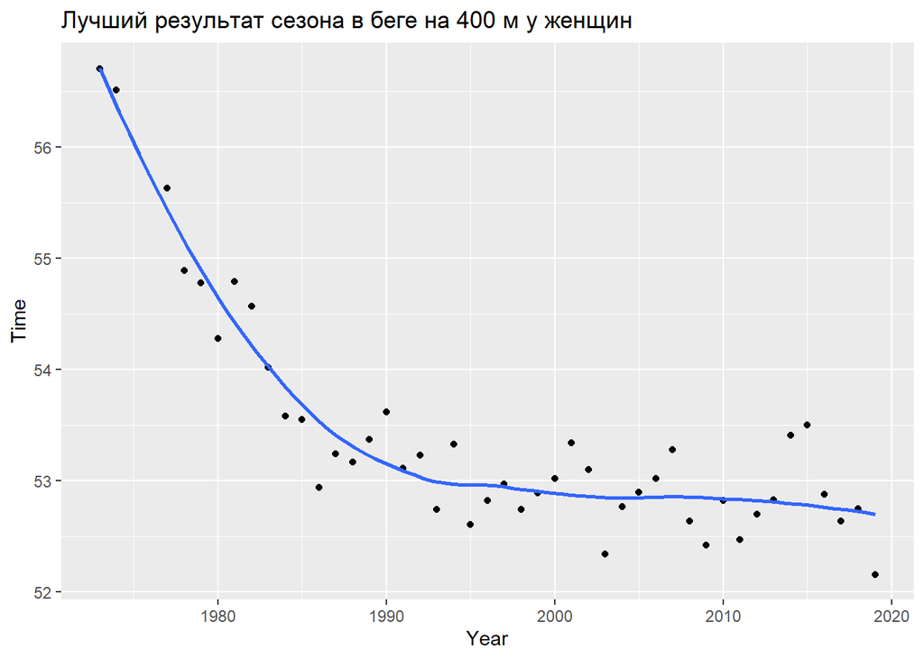

```r
runners %>%
  ggplot(aes(Year, Time)) +
  geom_point() +
  geom_smooth(se = F) +
  labs(title = 'Лучший результат сезона в беге на 400 м у женщин')
```

Очевидна нелинейная зависимость: до 1990 года результаты улучшались, затем вышли на плато.

# Построение моделей

## Модель линейной регрессии

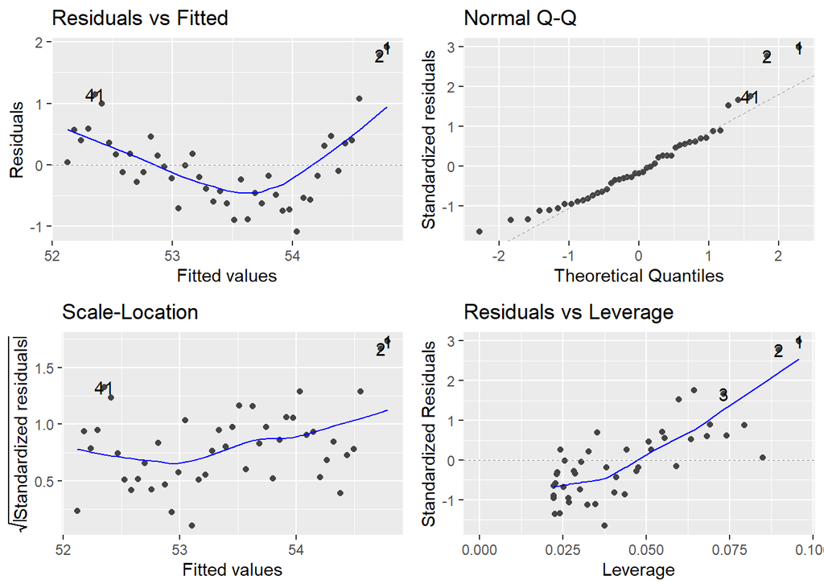

```r
m_lin <- lm(Time ~ Year, data = runners)
autoplot(m_lin)
```

В остатках видна нелинейная зависимость.

Подготовим таблицу с прогнозом и визуализируем результат. Поскольку прогноз потребуется в дальнейшем для сравнения ошибки разных моделей, построим его на тех же данных, по которым строилась модель. Для этих данных известны фактические значения, которые нужны для расчета ошибки.

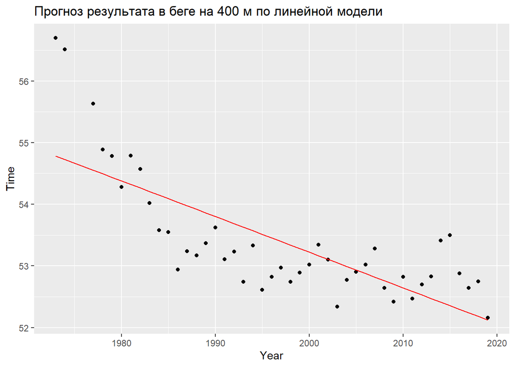

```r
pred_lin <-
  runners %>%
  add_predictions(m_lin, var = "Predicted") %>%
  select(Year, Time, Predicted)

pred_lin %>%
  ggplot(aes(Year, Time)) +
  geom_point() +
  geom_line(aes(Year, Predicted), color = "red") +
  labs(title = "Прогноз результата в беге на 400 м по линейной модели")
```

## Модель с логарифмом для Y

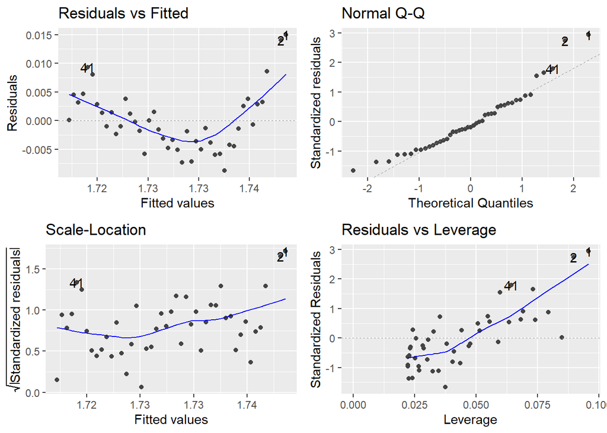

```r
m_log <- lm(log10(Time) ~ Year, data = runners)
autoplot(m_log)
```

Ситуация с остатками не улучшилась.

При построении прогноза обратим внимание, что в этой модели была преобразована зависимая переменная. Функции `predict()` и `add_predictions()` будут строить прогноз для зависимой переменной в логарифмической шкале. Результат необходимо преобразовать в исходную шкалу вручную.

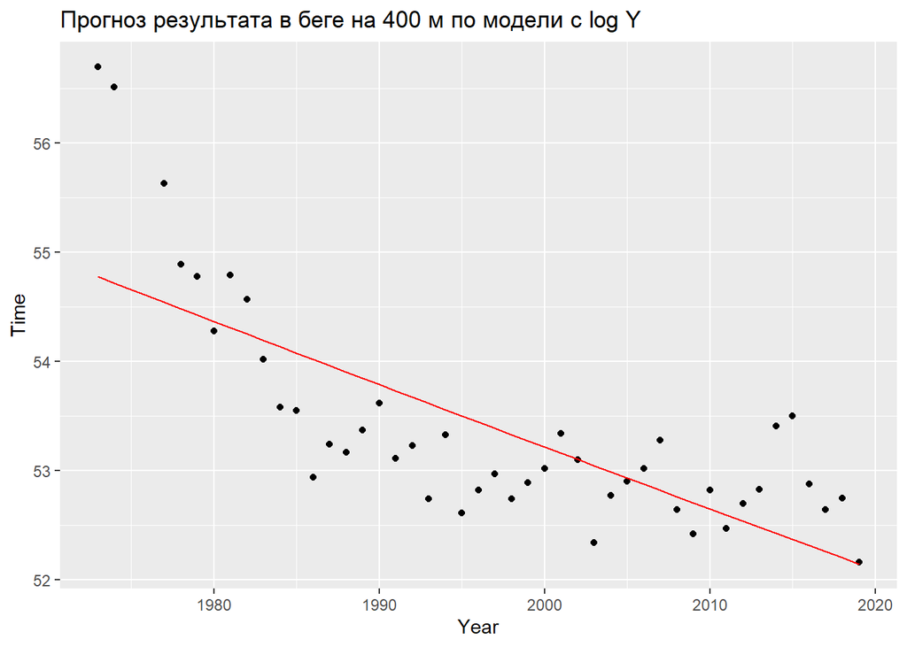

```r
pred_log <-
  runners %>%
  add_predictions(m_log, var = "Predicted") %>%
  select(Year, Time, Predicted) %>% # Прогноз логарифма результата
  mutate(Predicted = 10^Predicted)

pred_log %>%
  ggplot(aes(Year, Time)) +
  geom_point() +
  geom_line(aes(Year, Predicted), color = "red") +
  labs(title = "Прогноз результата в беге на 400 м по модели с log Y")
```

Прогноз по логарифмической модели очень похож на прогноз по линейной модели.

## Модель с логарифмом для X

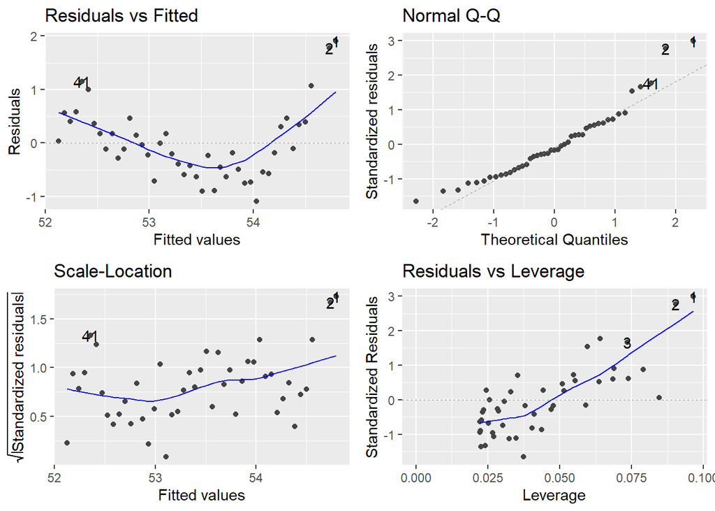

```r
m_logx <- lm(Time ~ log10(Year), data = runners)
autoplot(m_logx)
```

Ситуация с остатками не улучшилась.

В этой модели зависимая переменная не преобразовывалась, поэтому прогноз получаем сразу в нужной шкале.

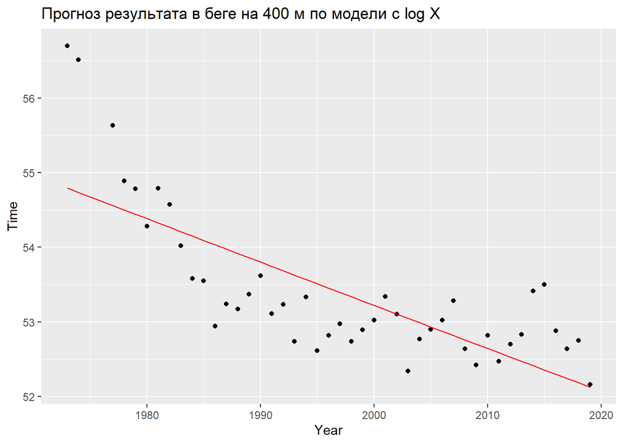

```r
pred_logx <-
  runners %>%
  add_predictions(m_logx, var = "Predicted") %>% # Не надо преобразовывать Y
  select(Year, Time, Predicted)

pred_logx %>%
  ggplot(aes(Year, Time)) +
  geom_point() +
  geom_line(aes(Year, Predicted), color = "red") +
  labs(title = "Прогноз результата в беге на 400 м по модели с log X")
```

Прогноз не отличается от предыдущих.

## Модель с корнем Y

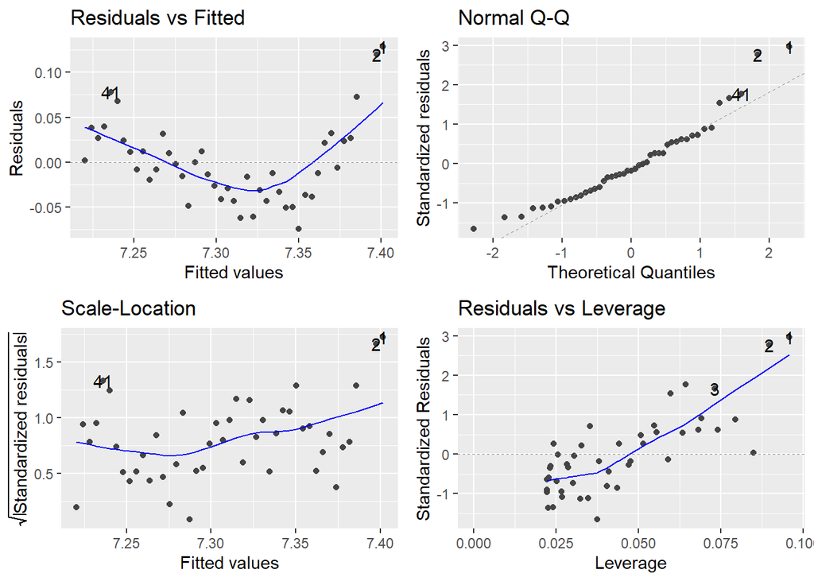

```r
m_sqrt <- lm(sqrt(Time) ~ Year, data = runners)
autoplot(m_sqrt)
```

Ситуация с остатками не улучшилась.

Посчитаем прогноз. Здесь преобразовывали Y, поэтому нужно пересчитать прогноз в исходную шкалу.

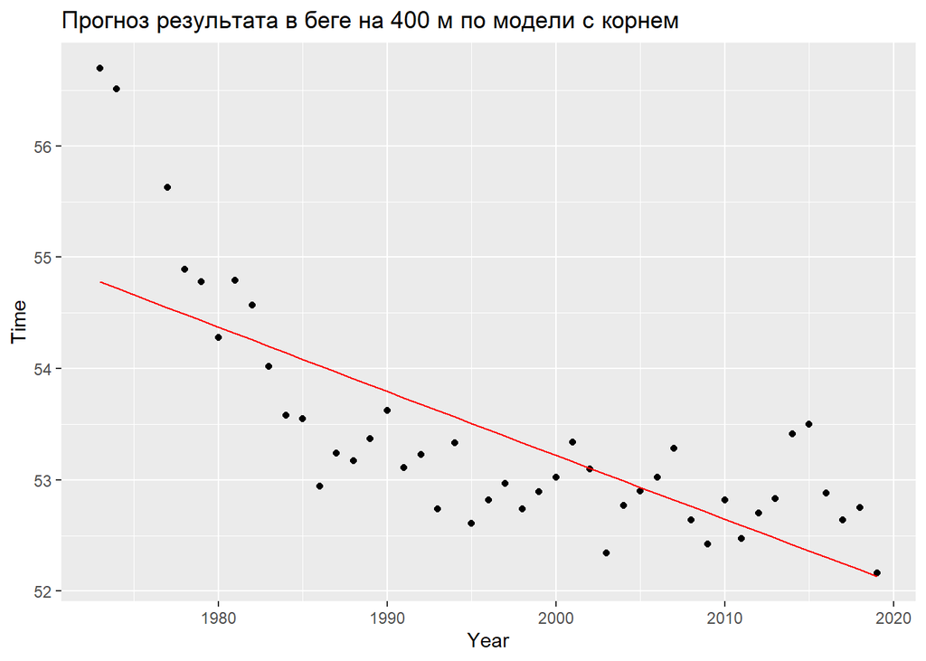

```r
pred_sqrt <-
  runners %>%
  add_predictions(m_sqrt, var = "Predicted") %>%
  select(Year, Time, Predicted) %>% # Прогноз логарифма результата
  mutate(Predicted = Predicted^2)

pred_sqrt %>%
  ggplot(aes(Year, Time)) +
  geom_point() +
  geom_line(aes(Year, Predicted), color = "red") +
  labs(title = "Прогноз результата в беге на 400 м по модели с корнем")
```

## Модель с 1/Y

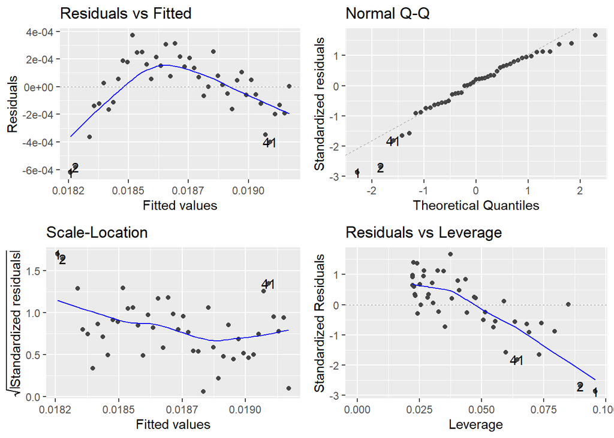

```r
m_inv <- lm(1/Time ~ Year, data = runners)
autoplot(m_inv)
```

Ситуация с остатками не улучшилась.

Прогноз также надо пересчитать в исходную шкалу.

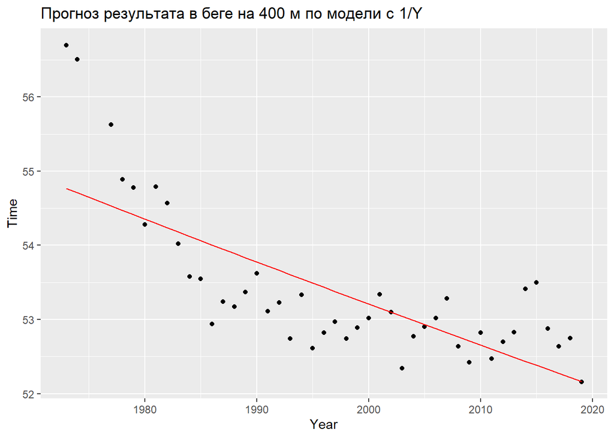

```r
pred_inv <-
  runners %>%
  add_predictions(m_inv, var = "Predicted") %>%
  select(Year, Time, Predicted) %>% # Прогноз 1/результата
  mutate(Predicted = 1/Predicted)

pred_inv %>%
  ggplot(aes(Year, Time)) +
  geom_point() +
  geom_line(aes(Year, Predicted), color = "red") +
  labs(title = "Прогноз результата в беге на 400 м по модели с 1/Y")
```

## Модель с преобразованием Бокса-Кокса

Определим параметр степенного преобразования, дающий наиболее близкое к нормальному распределение остатков.

```r
powerTransform(m_lin)
```

```
## Estimated transformation parameter
##    Y1
## -6.47
```

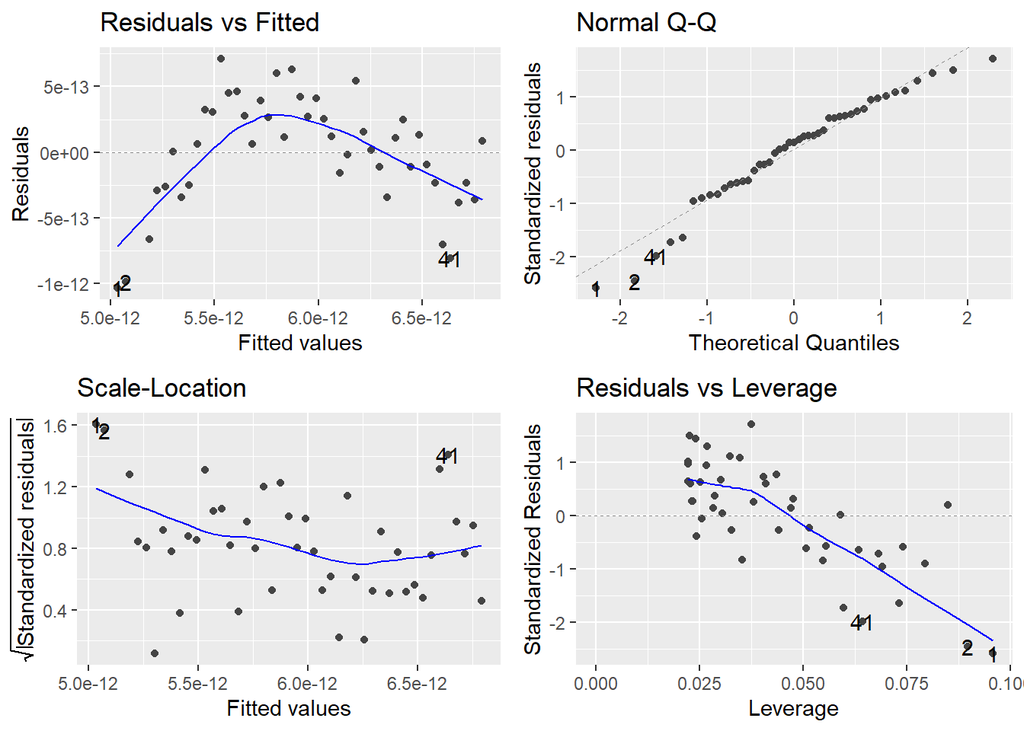

```r
m_pow <- lm(Time^-6.5 ~ Year, data = runners)
autoplot(m_pow)
```

Результат по-прежнему плохой.

Считаем прогноз, не забыв применить обратное преобразование.

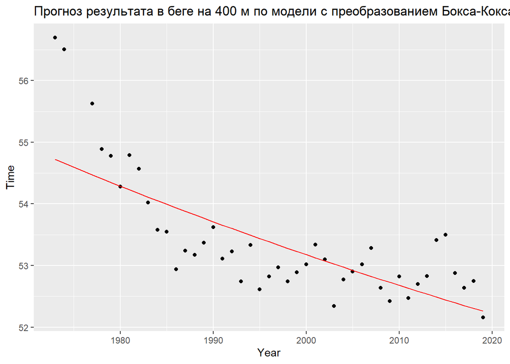

```r
pred_pow <-
  runners %>%
  add_predictions(m_pow, var = "Predicted") %>%
  select(Year, Time, Predicted) %>% # Прогноз 1/результата
  mutate(Predicted = Predicted^(1/-6.5))

pred_pow %>%
  ggplot(aes(Year, Time)) +
  geom_point() +
  geom_line(aes(Year, Predicted), color = "red") +
  labs(title = "Прогноз результата в беге на 400 м по модели с преобразованием Бокса-Кокса")
```

## Полиномиальная модель

Попробуем построить модель с полиномом второй степени:

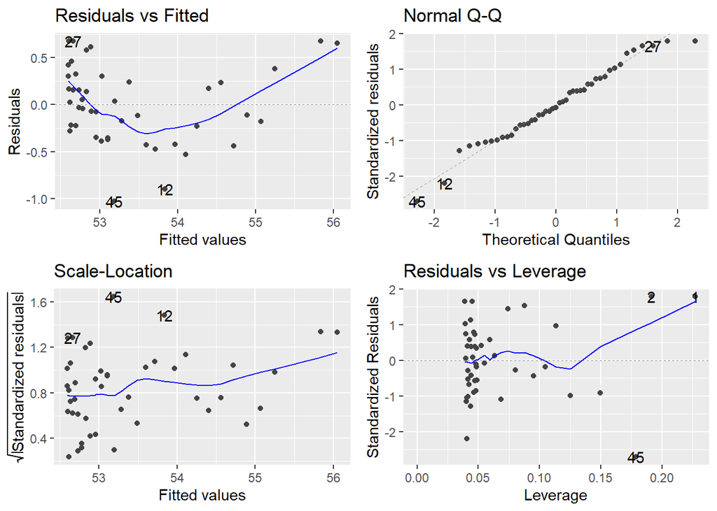

```r
m_poly <- lm(Time ~ poly(Year, 2, raw = T), data = runners)
autoplot(m_poly)
```

Результат лучше, чем предыдущие - распределение меньше отличается от нормального и менее выражена нелинейность остатков.

Попробуем полином 3 степени:

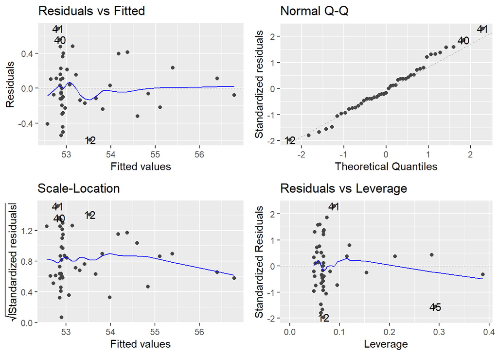

```r
m_poly <- lm(Time ~ poly(Year, 3, raw = T), data = runners)
autoplot(m_poly)
```

Результат обнадеживающий.

Строим прогноз по полиномиальной модели. Он сразу получается в исходной шкале, т.к. Y не преобразовывали.

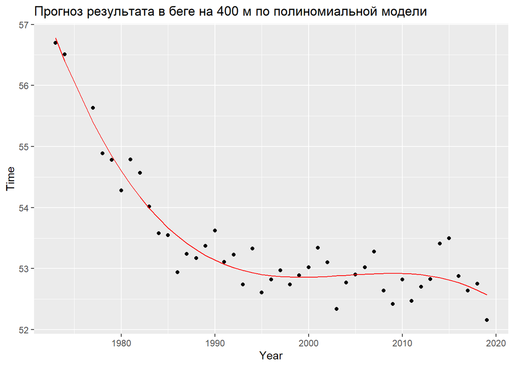

```r
pred_poly <-
  runners %>%
  add_predictions(m_poly, var = "Predicted") %>%
  select(Year, Time, Predicted)

pred_poly %>%
  ggplot(aes(Year, Time)) +
  geom_point() +
  geom_line(aes(Year, Predicted), color = "red") +
  labs(title = "Прогноз результата в беге на 400 м по полиномиальной модели")
```

# Сравнение моделей

## Функция для расчета ошибок

Поскольку нам необходимо сравнить множество моделей, создадим функцию, которая вычисляет необходимые показатели ошибки на основе двух векторов - факт и прогноз.

```r
errors <- function(actual, predicted) {
  error <- actual - predicted
  abs_error <- abs(actual - predicted)
  percent_error <- abs_error/actual

  ME <- mean(error, na.rm = T)
  MAE <- mean(abs_error, na.rm = T)
  MAPE <- mean(percent_error, na.rm = T)
  MSE <- mean(error^2, na.rm = T)
  RMSE <- sqrt(MSE)

  tibble(ME, MAE, MAPE, MSE, RMSE)
}
```

Пробуем применить функцию к прогнозу по линейной модели:

```r
errors(pred_lin$Time, pred_lin$Predicted)
```

```
## # A tibble: 1 x 5
##          ME   MAE    MAPE   MSE  RMSE
##       <dbl> <dbl>   <dbl> <dbl> <dbl>
## 1 -1.42e-15 0.511 0.00950 0.433 0.658
```

Или так, чтобы не писать $:

```r
pred_lin %>%
  with(errors(Time, Predicted))
```

```
## # A tibble: 1 x 5
##          ME   MAE    MAPE   MSE  RMSE
##       <dbl> <dbl>   <dbl> <dbl> <dbl>
## 1 -1.42e-15 0.511 0.00950 0.433 0.658
```

## Сравнение моделей

Мы могли бы вручную применить теперь функцию к каждой таблице прогноза и сравнить результаты, но лучше сделать это автоматически, сразу для всех моделей.

Чтобы понимать, что происходит, прочитайте главу [Many Models](https://r4ds.had.co.nz/many-models.html) в книге R for Data Science.

Объединим все прогнозы в одну таблицу с помощью функции `bind_rows()`. Эта функция позволяет удобно подписать, из какой исходной таблицы взята каждая строка. Затем сгруппируем данные по названию модели и для каждой группы применим нашу функцию для расчета ошибок.

Объяснения [тут](https://r4ds.had.co.nz/many-models.html#creating-list-columns).

```r
all_models <-
  bind_rows("Линейная модель" = pred_lin,
          "Модель с log Y" = pred_log,
          "Модель с log X" = pred_logx,
          "Модель с 1/Y" = pred_inv,
          "Модель с sqrt Y" = pred_sqrt,
          "Модель Бокса-Кокса" = pred_pow,
          "Полиномиальная модель" = pred_poly,
          .id = "Model")

all_models %>%
  group_by(Model) %>%
  summarise(errors = list(errors(Time, Predicted))) %>%
  unnest() %>%
  arrange(MAPE) %>%
  knitr::kable()
```

| Model | ME | MAE | MAPE | MSE | RMSE |
| --- | --- | --- | --- | --- | --- |
| Полиномиальная модель | 0.000 | 0.240 | 0.004 | 0.088 | 0.297 |
| Модель Бокса-Кокса | 0.031 | 0.478 | 0.009 | 0.404 | 0.636 |
| Модель с 1/Y | 0.008 | 0.500 | 0.009 | 0.423 | 0.650 |
| Модель с log Y | 0.004 | 0.505 | 0.009 | 0.428 | 0.654 |
| Модель с sqrt Y | 0.002 | 0.508 | 0.009 | 0.430 | 0.656 |
| Модель с log X | 0.000 | 0.510 | 0.009 | 0.430 | 0.656 |
| Линейная модель | 0.000 | 0.511 | 0.009 | 0.433 | 0.658 |

Лучший по MAPE результат получился по полиномиальной модели. Остальные модели по этому показателю не различаются и примерно в 2 раза хуже.